# StreetLaw Summary

Matt Motyl, CivilPolitics.org

July 15, 2019

## Key

Here is the question key containing the exact wording of the question asked in each survey.

|  | Question Wording |
| --- | --- |
| Others are Good | People who hold different views on controversial issues are generally just as good as people who hold similar views as me. |
| Would Friend Others | If I learn that someone holds different controversial views than I do, I become less interested in being friends with him/her.* |
| Others are Smart | Intelligent people may hold different views from me. |
| Respect Others | I respect people who disagree with my views. |
| Similar Others Smart | Generally, intelligent people hold similar views as mine. |
| Like Similarity | I strongly prefer talking with people who share my views on controversial issues than people who do not share my views. |
| Like Disconfirming Info | I like finding out new information that differs what I already think is true. |
| Question Beliefs | I question my own opinions, positions, and viewpoints because they could be wrong. |
| Generation Difference | People born in a different generation provide important perspectives on controversial topics. |
| Understand Beliefs | I feel like I understand better why someone holds different beliefs on the controversial issue after communicating with them. |
| Talk to Others | I am interested in talking about controversial issues with people who hold different beliefs from me. |
| Understand Perspective | After talking to people with different beliefs on controversial issues, I understand their perspective better. |

## Overall Results

To examine whether participants showed improvement from Time 1 to Time 2, I matched their unique id numbers and plotted the mean score for all participants at each time point below.

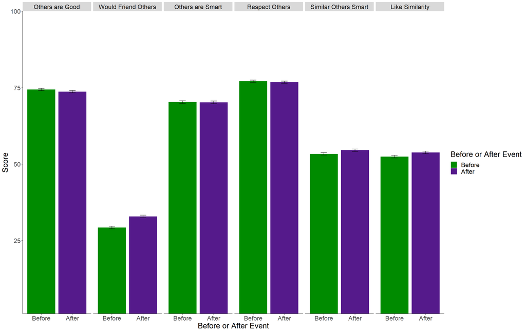

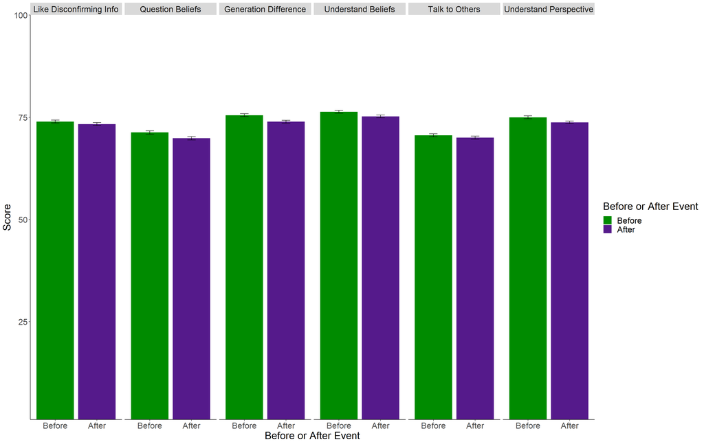

Overall, there was a positive effect where participants reported that they would become more interested in being friends with people holding different beliefs on controversial issues from them at time 2 relative to time 1. Unexpectedly, there was a small negative effect where participants reported a decrease in their belief that “People born in a different generation provide important perspectives on controversial topics.” Responses to all other questions did not differ between time 1 and time 2.

|  | Pre Score | Post Score | T-value | Effect Size (D) | P-value | Standard Error | Effect |
| --- | --- | --- | --- | --- | --- | --- | --- |
| Like Disconfirming Info | 73.956 | 73.344 | -0.873 | 0.028 | 0.383 | 0.350 | No |
| Question Beliefs | 71.278 | 69.862 | -1.841 | 0.058 | 0.066 | 0.384 | No |
| Would Friend Others | 29.219 | 32.851 | 4.401 | 0.139 | 0.000 | 0.411 | Yes |
| Others are Good | 74.411 | 73.707 | -0.922 | 0.029 | 0.357 | 0.381 | No |
| Respect Others | 77.125 | 76.808 | -0.449 | 0.014 | 0.653 | 0.353 | No |
| Others are Smart | 70.299 | 70.222 | -0.089 | 0.003 | 0.929 | 0.434 | No |
| Talk to Others | 70.590 | 70.036 | -0.726 | 0.023 | 0.468 | 0.382 | No |
| Understand Perspective | 75.000 | 73.752 | -1.848 | 0.058 | 0.065 | 0.337 | No |
| Understand Beliefs | 76.355 | 75.193 | -1.768 | 0.056 | 0.077 | 0.328 | No |
| Generation Difference | 75.515 | 73.925 | -2.265 | 0.072 | 0.024 | 0.350 | Yes |
| Similar Others Smart | 53.348 | 54.537 | 1.546 | 0.049 | 0.122 | 0.384 | No |
| Like Similarity | 52.428 | 53.794 | 1.628 | 0.051 | 0.104 | 0.419 | No |

## Results by Region

I broke down the results of each event by location of the event. Each section will be presented:

- graphically, showing the change in response to each applicable question
- descriptively, showing the means and standard deviations for each question

*Press Key to return to the Question Key.

|  | Surveys Collected |
| --- | --- |
| Denver (Pre) | 1350 |
| Denver (Post) | 1058 |
| DMV (Pre) | 388 |
| DMV (Post) | 485 |
| Number of Omaha (Pre) | 391 |
| Omaha (Post) | 359 |

### OMAHA

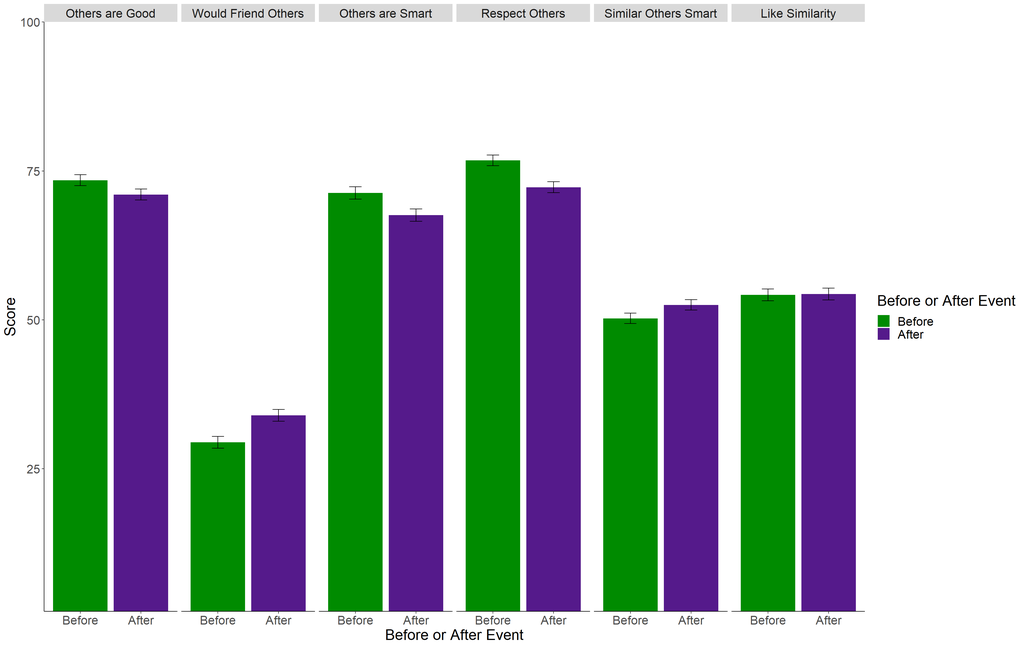

[figure not shown]

In the Omaha subsample, there was a positive effect where participants reported that they would become more interested in being friends with people holding different beliefs on controversial issues from them at time 2 relative to time 1. Unexpectedly, participants reported that they were less likely to question their own beliefs and respect people with different beliefs. Additionally, participants reported decreased understanding of why people hold different beliefs on controversial issues after communicating with them. Responses to all other questions did not differ between time 1 and time 2.

All summary statistics are included in the table below.

|  | Pre Score | Post Score | T-value | Effect Size (D) | P-value | Standard Error | Effect |
| --- | --- | --- | --- | --- | --- | --- | --- |
| Like Disconfirming Info | 70.611 | 68.167 | -1.319 | 0.097 | 0.188 | 0.925 | No |
| Question Beliefs | 68.586 | 64.000 | -2.376 | 0.174 | 0.018 | 0.965 | Yes |
| Would Friend Others | 29.425 | 33.958 | 2.303 | 0.169 | 0.022 | 0.985 | Yes |
| Others are Good | 73.435 | 71.019 | -1.310 | 0.096 | 0.191 | 0.920 | No |
| Respect Others | 76.785 | 72.265 | -2.506 | 0.184 | 0.012 | 0.901 | Yes |
| Others are Smart | 71.292 | 67.574 | -1.782 | 0.130 | 0.075 | 1.043 | No |
| Talk to Others | 66.425 | 64.187 | -1.151 | 0.084 | 0.250 | 0.970 | No |
| Understand Perspective | 72.315 | 70.117 | -1.271 | 0.093 | 0.204 | 0.862 | No |
| Understand Beliefs | 72.795 | 69.056 | -2.167 | 0.159 | 0.031 | 0.860 | Yes |
| Generation Difference | 71.535 | 70.100 | -0.814 | 0.060 | 0.416 | 0.877 | No |
| Similar Others Smart | 50.235 | 52.501 | 1.272 | 0.093 | 0.204 | 0.888 | No |
| Like Similarity | 54.184 | 54.320 | 0.070 | 0.005 | 0.945 | 0.979 | No |

### DMV

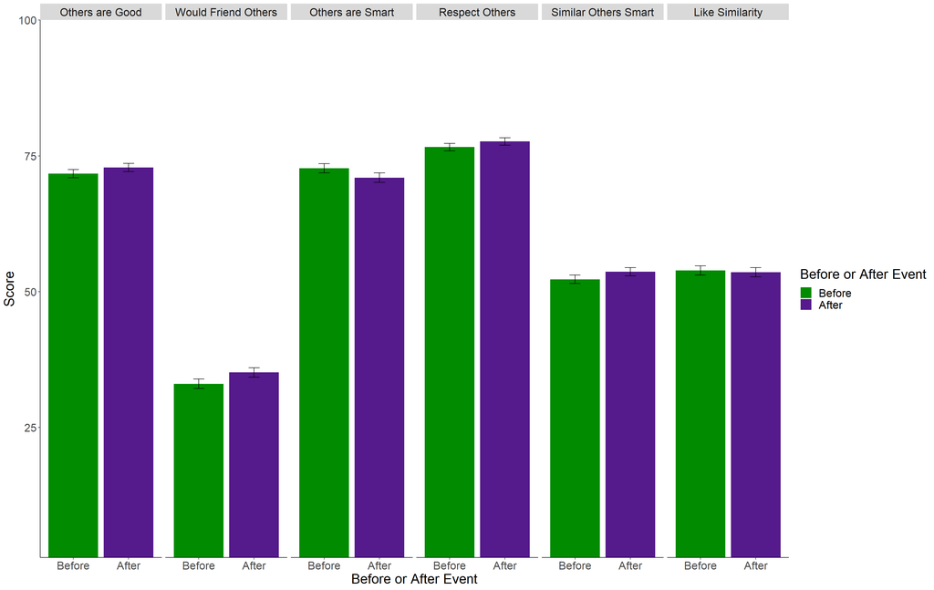

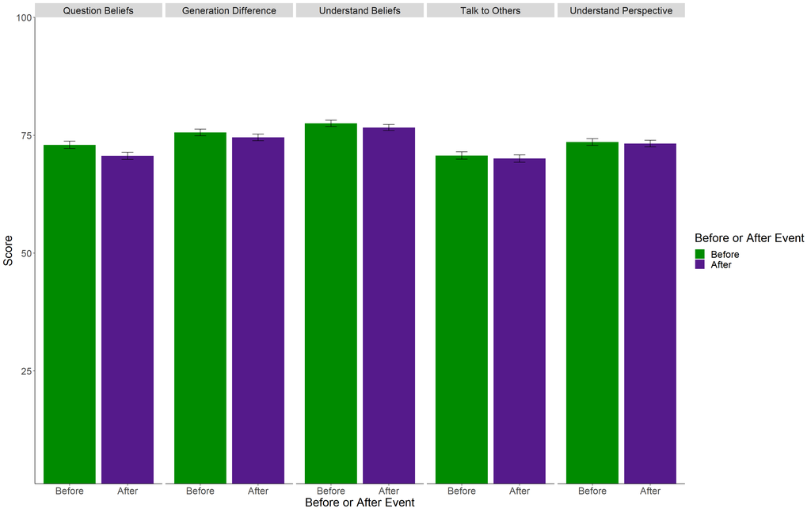

There were no statistically significant differences from Time 1 to Time 2 on any of the questions in the DMV region.

All summary statistics are included in the table below.

|  | Pre Score | Post Score | T-value | Effect Size (D) | P-value | Standard Error | Effect |
| --- | --- | --- | --- | --- | --- | --- | --- |
| Like Disconfirming Info | 75.544 | 73.115 | -1.788 | 0.121 | 0.074 | 0.682 | No |
| Question Beliefs | 72.966 | 70.629 | -1.539 | 0.104 | 0.124 | 0.764 | No |
| Would Friend Others | 33.021 | 35.105 | 1.211 | 0.082 | 0.226 | 0.860 | No |
| Others are Good | 71.727 | 72.872 | 0.759 | 0.052 | 0.448 | 0.751 | No |
| Respect Others | 76.608 | 77.647 | 0.760 | 0.051 | 0.447 | 0.683 | No |
| Others are Smart | 72.732 | 70.992 | -1.017 | 0.069 | 0.309 | 0.854 | No |
| Talk to Others | 70.698 | 70.052 | -0.412 | 0.028 | 0.681 | 0.776 | No |
| Understand Perspective | 73.582 | 73.225 | -0.251 | 0.017 | 0.802 | 0.706 | No |
| Understand Beliefs | 77.531 | 76.647 | -0.676 | 0.046 | 0.499 | 0.649 | No |
| Generation Difference | 75.598 | 74.546 | -0.727 | 0.049 | 0.467 | 0.723 | No |
| Similar Others Smart | 52.265 | 53.654 | 0.907 | 0.061 | 0.365 | 0.767 | No |
| Like Similarity | 53.902 | 53.581 | -0.187 | 0.013 | 0.852 | 0.855 | No |

### DENVER

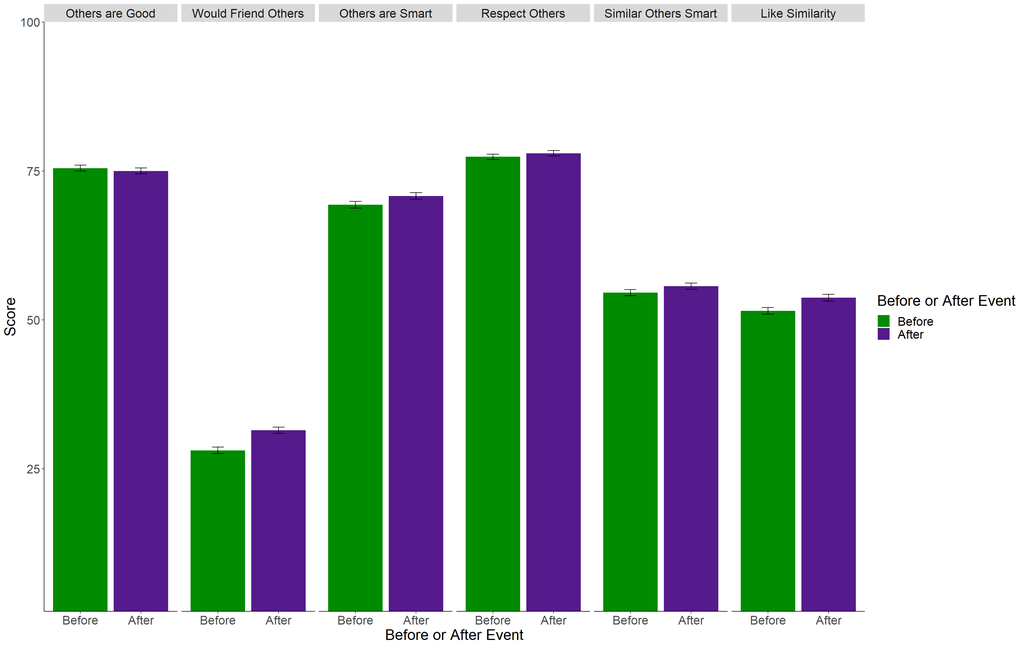

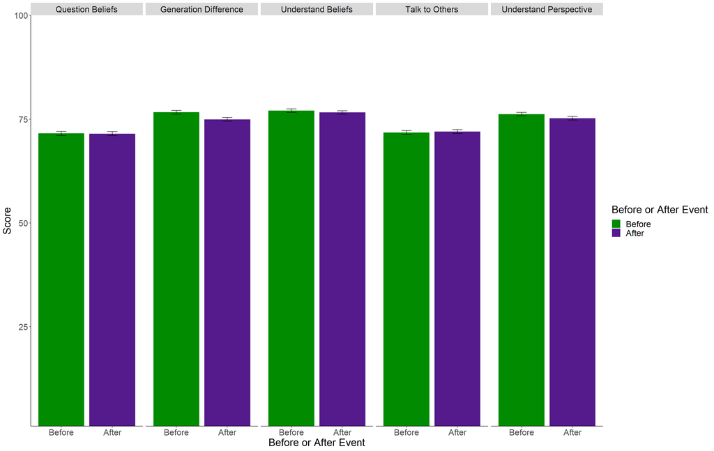

In the Denver subsample, there was a positive effect where participants reported that they would become more interested in being friends with people holding different beliefs on controversial issues from them at time 2 relative to time 1. Unexpectedly, participants reported a slight increase in their liking for communicating with people who hold similar beliefs as them.Responses to all other questions did not differ between time 1 and time 2.

All summary statistics are included in the table below.

|  | Pre Score | Post Score | T-value | Effect Size (D) | P-value | Standard Error | Effect |
| --- | --- | --- | --- | --- | --- | --- | --- |
| Like Disconfirming Info | 74.473 | 75.207 | 0.827 | 0.034 | 0.408 | 0.443 | No |
| Question Beliefs | 71.575 | 71.500 | -0.076 | 0.003 | 0.940 | 0.493 | No |
| Would Friend Others | 28.067 | 31.441 | 3.137 | 0.130 | 0.002 | 0.530 | Yes |
| Others are Good | 75.464 | 75.001 | -0.462 | 0.019 | 0.644 | 0.500 | No |
| Respect Others | 77.373 | 77.965 | 0.648 | 0.026 | 0.517 | 0.456 | No |
| Others are Smart | 69.313 | 70.767 | 1.274 | 0.052 | 0.203 | 0.570 | No |
| Talk to Others | 71.777 | 72.015 | 0.246 | 0.010 | 0.806 | 0.484 | No |
| Understand Perspective | 76.197 | 75.229 | -1.134 | 0.047 | 0.257 | 0.422 | No |
| Understand Beliefs | 77.055 | 76.609 | -0.535 | 0.022 | 0.593 | 0.413 | No |
| Generation Difference | 76.655 | 74.939 | -1.912 | 0.079 | 0.056 | 0.444 | No |
| Similar Others Smart | 54.560 | 55.632 | 1.050 | 0.043 | 0.294 | 0.508 | No |
| Like Similarity | 51.496 | 53.713 | 2.006 | 0.082 | 0.045 | 0.551 | Yes |

## Results by Community Level

I broke down the results of each event by location of the event. Each section will be presented:

- graphically, showing the change in response to each applicable question
- descriptively, showing the means and standard deviations for each question

*Press Key to return to the Question Key.

In the table below we have the number of respondents for which we have pre and post event data by type of sample.

|  | Surveys Collected |
| --- | --- |
| Classroomn (Pre) | 1422 |
| Classroom (Post) | 1106 |
| Community - Nonstudent (Pre) | 56 |
| Community - Nonstudent (Post) | 106 |
| Community - Student (Pre) | 576 |
| Community - Student(Post) | 616 |

### CLASSROOM

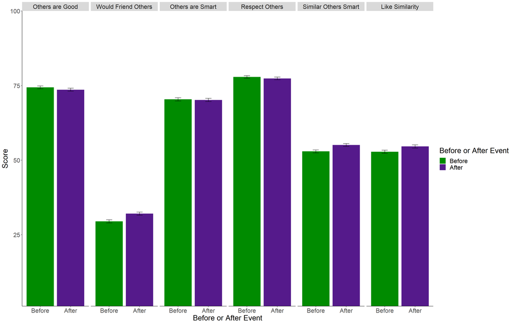

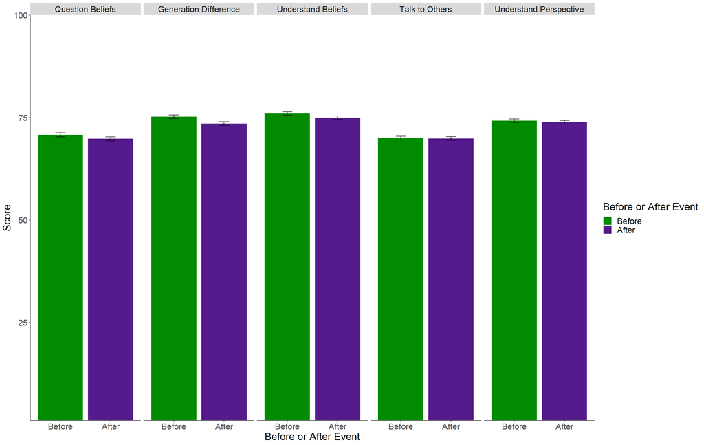

In the classroom subsample, there was a positive effect where participants reported that they would become more interested in being friends with people holding different beliefs on controversial issues from them at time 2 relative to time 1. Unexpectedly, participants reported a slight increase in their belief that people who share similar beliefs on controversial issues were smarter than people who held different beliefs on controversial beliefs. Responses to all other questions did not differ between time 1 and time 2.

All summary statistics are included in the table below.

|  | Pre Score | Post Score | T-value | Effect Size (D) | P-value | Standard Error | Effect |
| --- | --- | --- | --- | --- | --- | --- | --- |
| Like Disconfirming Info | 73.150 | 73.424 | 0.301 | 0.012 | 0.763 | 0.449 | No |
| Question Beliefs | 70.795 | 69.815 | -0.990 | 0.040 | 0.322 | 0.488 | No |
| Would Friend Others | 29.461 | 32.045 | 2.460 | 0.099 | 0.014 | 0.518 | Yes |
| Others are Good | 74.418 | 73.630 | -0.817 | 0.033 | 0.414 | 0.478 | No |
| Respect Others | 77.890 | 77.402 | -0.552 | 0.022 | 0.581 | 0.435 | No |
| Others are Smart | 70.398 | 70.175 | -0.203 | 0.008 | 0.839 | 0.544 | No |
| Talk to Others | 69.985 | 69.880 | -0.107 | 0.004 | 0.915 | 0.488 | No |
| Understand Perspective | 74.216 | 73.860 | -0.413 | 0.017 | 0.679 | 0.426 | No |
| Understand Beliefs | 75.989 | 74.988 | -1.187 | 0.048 | 0.235 | 0.416 | No |
| Generation Difference | 75.197 | 73.533 | -1.847 | 0.075 | 0.065 | 0.444 | No |
| Similar Others Smart | 52.928 | 55.071 | 2.208 | 0.089 | 0.027 | 0.480 | Yes |
| Like Similarity | 52.822 | 54.585 | 1.663 | 0.067 | 0.096 | 0.526 | No |

### COMMUNITY - STUDENT

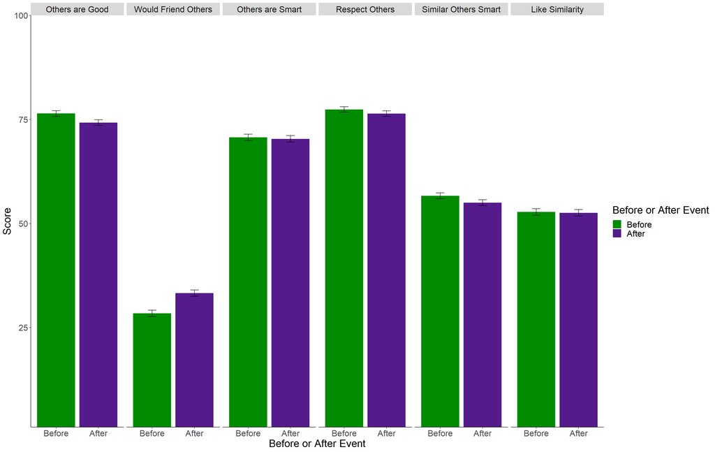

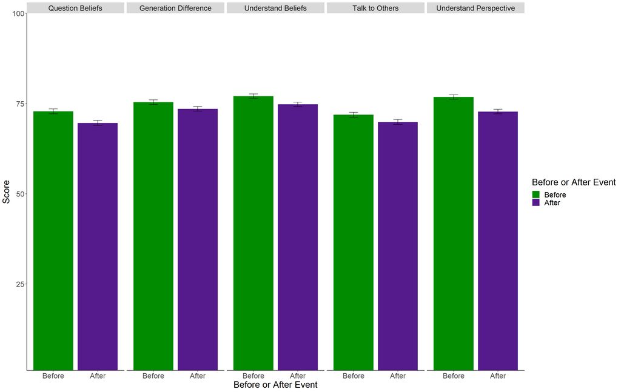

In the community student subsample, there was a positive effect where participants reported that they would become more interested in being friends with people holding different beliefs on controversial issues from them at time 2 relative to time 1. Unexpectedly, participants reported more aversion to information that challenges their beliefs, a decreased likelihood of questioning their own beliefs, and a decreased perception that communicating with people who hold different beliefs improves their understanding of their beliefs. Responses to all other questions did not differ between time 1 and time 2.

All summary statistics are included in the table below.

|  | Pre Score | Post Score | T-value | Effect Size (D) | P-value | Standard Error | Effect |
| --- | --- | --- | --- | --- | --- | --- | --- |
| Like Disconfirming Info | 75.132 | 72.373 | -2.150 | 0.125 | 0.032 | 0.641 | Yes |
| Question Beliefs | 72.832 | 69.610 | -2.329 | 0.135 | 0.020 | 0.692 | Yes |
| Would Friend Others | 28.391 | 33.226 | 3.224 | 0.187 | 0.001 | 0.754 | Yes |
| Others are Good | 76.417 | 74.239 | -1.612 | 0.093 | 0.107 | 0.675 | No |
| Respect Others | 77.389 | 76.390 | -0.777 | 0.045 | 0.437 | 0.641 | No |
| Others are Smart | 70.674 | 70.313 | -0.231 | 0.013 | 0.818 | 0.778 | No |
| Talk to Others | 71.892 | 69.903 | -1.439 | 0.084 | 0.150 | 0.690 | No |
| Understand Perspective | 76.811 | 72.779 | -3.252 | 0.188 | 0.001 | 0.623 | Yes |
| Understand Beliefs | 77.064 | 74.789 | -1.912 | 0.111 | 0.056 | 0.596 | No |
| Generation Difference | 75.384 | 73.521 | -1.454 | 0.084 | 0.146 | 0.641 | No |
| Similar Others Smart | 56.613 | 54.976 | -1.166 | 0.068 | 0.244 | 0.702 | No |
| Like Similarity | 52.748 | 52.542 | -0.133 | 0.008 | 0.894 | 0.774 | No |

### COMMUNITY - NONSTUDENT

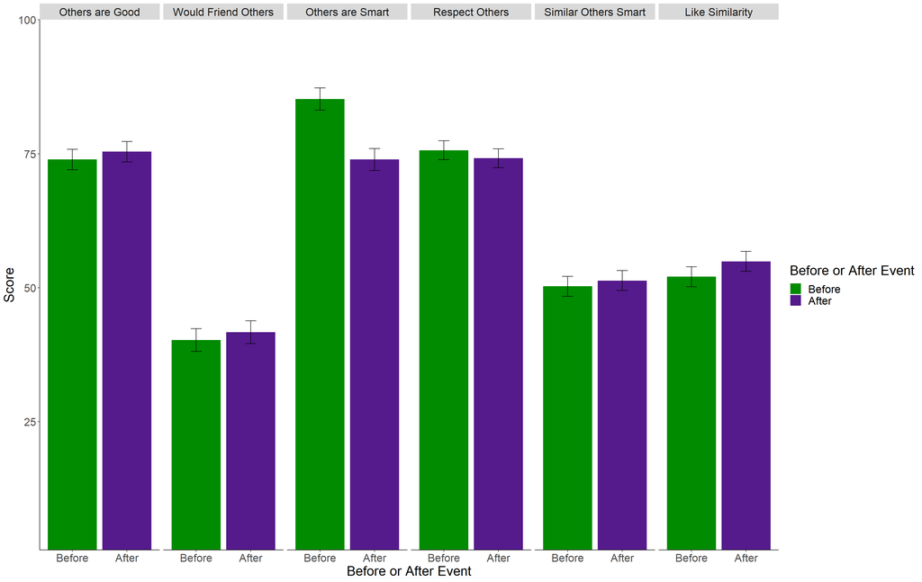

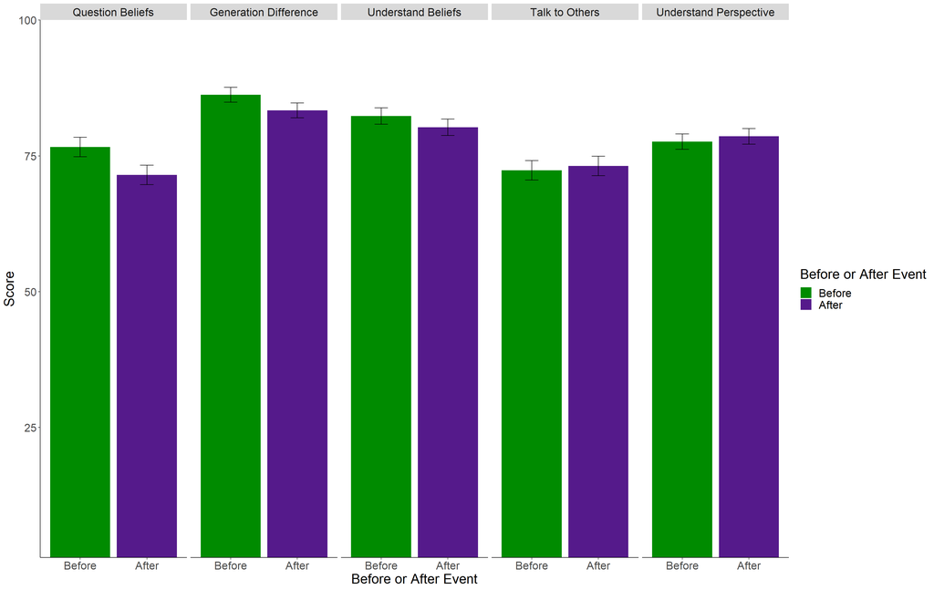

In the community nonstudent subsample, there were two unexpected, negative effects. First, participants reported liking information than challenges their beliefs less at Time 2 relative to Time 1. Second, participants reported viewing people who held different beliefs as less smart at time 2 relative to time 1.Responses to all other questions did not differ between time 1 and time 2.

All summary statistics are included in the table below.

|  | Pre Score | Post Score | T-value | Effect Size (D) | P-value | Standard Error | Effect |
| --- | --- | --- | --- | --- | --- | --- | --- |
| Like Disconfirming Info | 82.804 | 76.915 | -2.147 | 0.340 | 0.034 | 1.373 | Yes |
| Question Beliefs | 76.643 | 71.509 | -1.415 | 0.226 | 0.160 | 1.793 | No |
| Would Friend Others | 40.214 | 41.670 | 0.337 | 0.054 | 0.736 | 2.114 | No |
| Others are Good | 73.929 | 75.387 | 0.354 | 0.060 | 0.724 | 1.919 | No |
| Respect Others | 75.643 | 74.160 | -0.408 | 0.066 | 0.684 | 1.770 | No |
| Others are Smart | 85.214 | 73.934 | -2.910 | 0.439 | 0.004 | 2.055 | Yes |
| Talk to Others | 72.321 | 73.142 | 0.215 | 0.036 | 0.830 | 1.797 | No |
| Understand Perspective | 77.607 | 78.594 | 0.323 | 0.054 | 0.747 | 1.425 | No |
| Understand Beliefs | 82.357 | 80.274 | -0.685 | 0.108 | 0.495 | 1.508 | No |
| Generation Difference | 86.268 | 83.368 | -1.035 | 0.166 | 0.303 | 1.369 | No |
| Similar Others Smart | 50.250 | 51.321 | 0.267 | 0.045 | 0.790 | 1.852 | No |
| Like Similarity | 52.036 | 54.906 | 0.752 | 0.120 | 0.454 | 1.870 | No |

## Results by Topic

I broke down the results of each event by location of the event. Each section will be presented:

- graphically, showing the change in response to each applicable question
- descriptively, showing the means and standard deviations for each question

*Press Key to return to the Question Key.

In the table below we have the number of respondents for which we have pre and post event data by area.

|  | Surveys Collected |
| --- | --- |
| Assault Weapons (Pre) | 426 |
| Assault Weapons (Post) | 385 |
| Compulsory Voting (Pre) | 480 |
| Compulsory Voting (Post) | 348 |

### ASSAULT WEAPONS

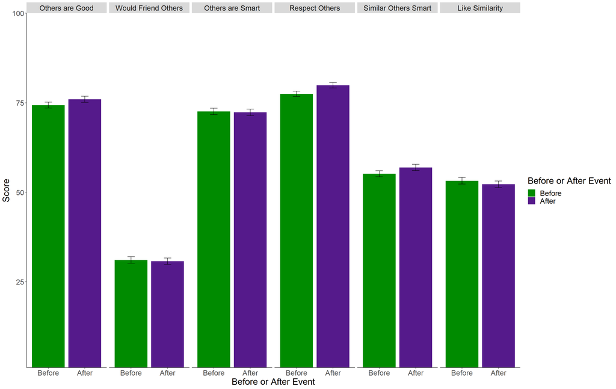

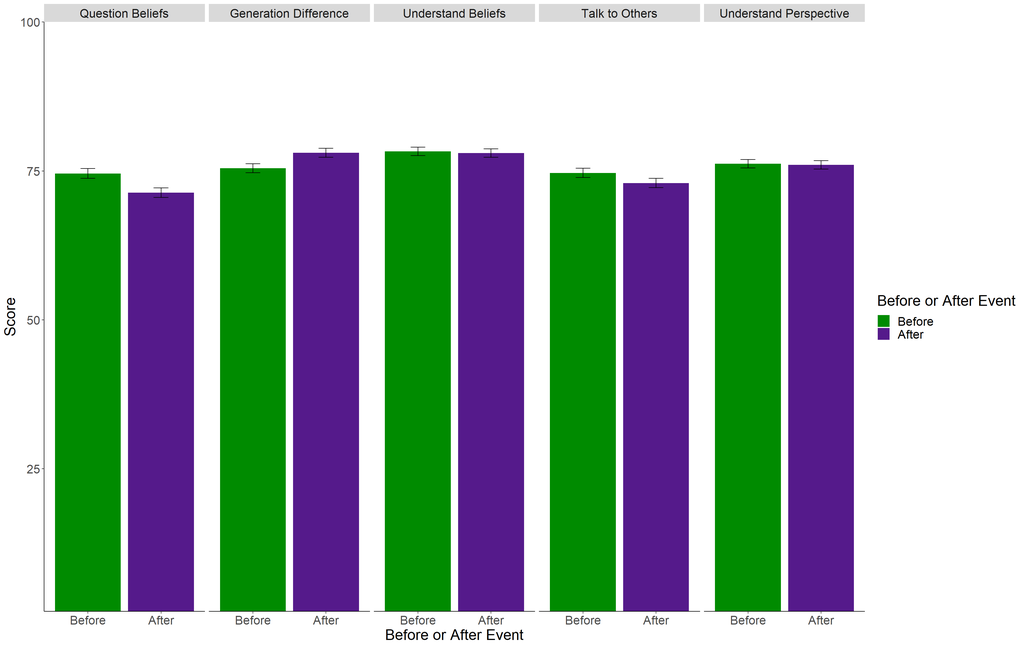

In the assault weapons dialogues, no responses differed between time 1 and time 2.

All summary statistics are included in the table below.

|  | Pre Score | Post Score | T-value | Effect Size (D) | P-value | Standard Error | Effect |
| --- | --- | --- | --- | --- | --- | --- | --- |
| Like Disconfirming Info | 75.859 | 75.499 | -0.237 | 0.017 | 0.812 | 0.760 | No |
| Question Beliefs | 74.566 | 71.353 | -1.962 | 0.139 | 0.050 | 0.815 | No |
| Would Friend Others | 31.085 | 30.751 | -0.185 | 0.013 | 0.854 | 0.903 | No |
| Others are Good | 74.326 | 75.966 | 0.991 | 0.070 | 0.322 | 0.828 | No |
| Respect Others | 77.493 | 79.886 | 1.634 | 0.115 | 0.103 | 0.734 | No |
| Others are Smart | 72.570 | 72.319 | -0.137 | 0.010 | 0.891 | 0.914 | No |
| Talk to Others | 74.655 | 72.971 | -1.076 | 0.076 | 0.282 | 0.781 | No |
| Understand Perspective | 76.204 | 76.000 | -0.145 | 0.010 | 0.885 | 0.705 | No |
| Understand Beliefs | 78.275 | 77.995 | -0.202 | 0.014 | 0.840 | 0.692 | No |
| Generation Difference | 75.434 | 78.052 | 1.736 | 0.122 | 0.083 | 0.756 | No |
| Similar Others Smart | 55.162 | 56.930 | 1.018 | 0.072 | 0.309 | 0.864 | No |
| Like Similarity | 53.200 | 52.231 | -0.521 | 0.037 | 0.602 | 0.927 | No |

### COMPULSORY VOTING

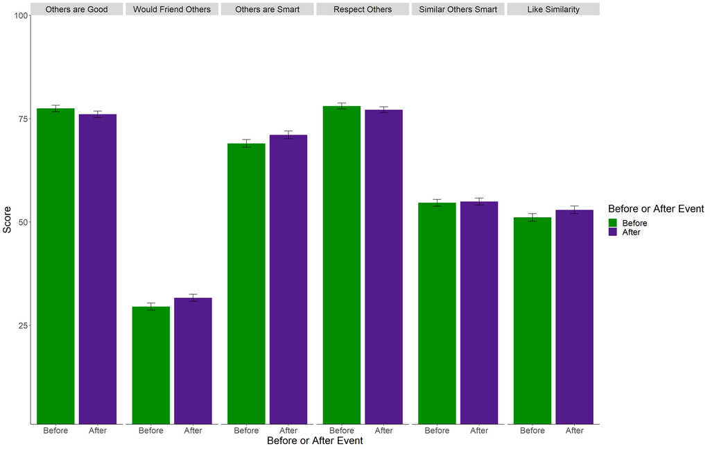

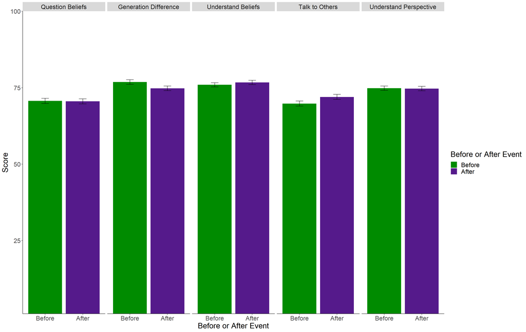

All summary statistics are included in the table below.

[output not shown]